# Representar el mundo en planos

Sistemas de representación: fundamentos · Clase 1.2 – Parte A

Expresión Gráfica · E.T.S.I. Montes, Forestal y del Medio Natural · UPM

# “Mundo 3D” → Plano 2D Sistemas de representación

## Sistemas de representación: proyecciones

**Proyectar** es llevar los puntos, líneas y planos de un OBJETO (3D) en dirección rectilínea sobre un PLANO (2D).

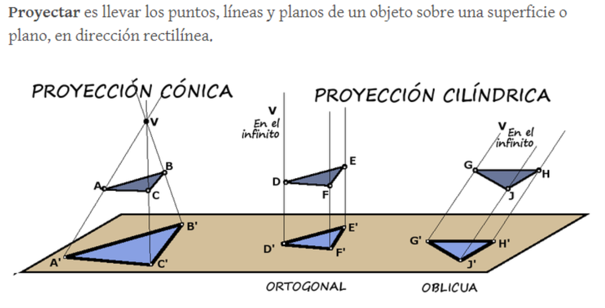

Elementos de una proyección:

- Objeto
- Punto de vista
- Plano de proyección o plano del cuadro
- Haz de rayos proyectantes

## Tipos de proyección

- **Cónica o central** — punto de vista a distancia finita
  - Perspectiva cónica
- **Cilíndrica** — punto de vista en el infinito
  - **Ortogonal**
    - Sistema diédrico
    - Axonométrico: isométrica, dimétrica, trimétrica
  - **Oblicua**
    - Caballera
    - Militar

**Representar 3D en 2D**  
Una sola vista = se ve bien, se mide mal  
Muchas vistas = se ve mal, se mide bien

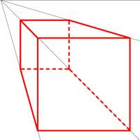

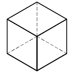

## Las ventajas de la proyección cónica: representación realista

[figure not shown]

La última cena. Leonardo da Vinci.

[figure not shown]

«Light After Light». Antonio Rojas.

Se **ve** bien, se **mide** mal

## La ventaja de las proyecciones cilíndricas: conservación de la razón simple

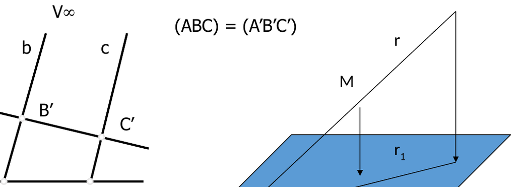

El dibujo técnico permite representar objetos tridimensionales en un formato bidimensional (papel) mediante las técnicas de proyección que se estudian en los sistemas de representación, en particular el Sistema Diédrico.

La utilización de **un sistema de proyección de tipo cilíndrico** (el centro de proyección se encuentra en el infinito) aporta interesantes ventajas desde el punto de vista métrico, ya que **se conserva la denominada razón simple** (derivada del **teorema de Thales**) en este tipo de proyecciones.

## Proyección cilíndrica sobre planos ortogonales. Sistema diédrico

El modelo de representación que usamos en dibujo técnico se apoya en **dos proyecciones (o tres) sobre planos ortogonales** entre sí.

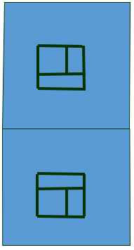

Se **ve** mal, se **mide** bien

## La proyección y el abatimiento, paso a paso

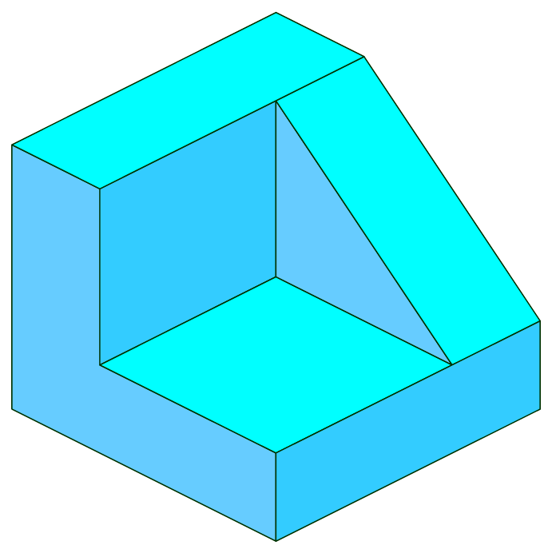

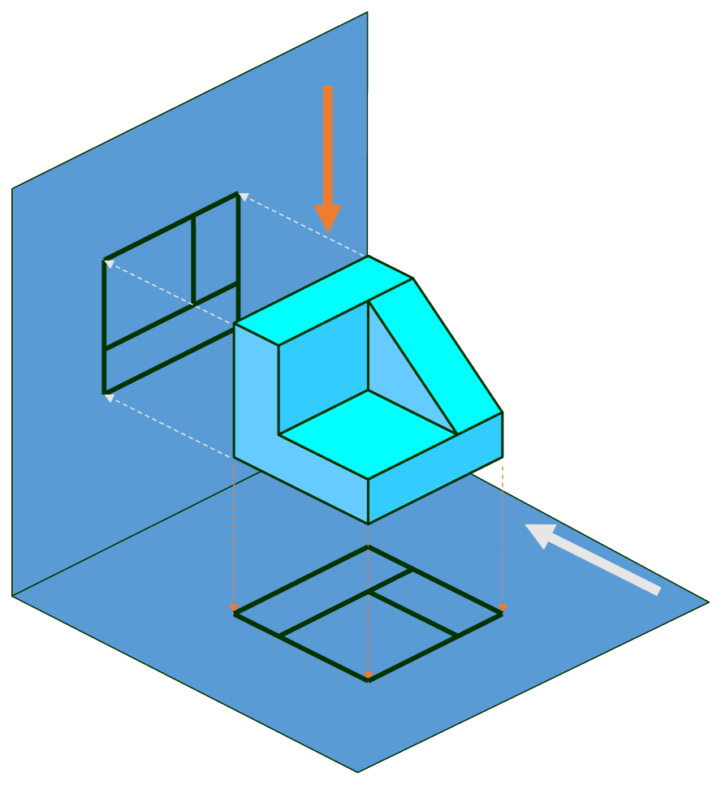

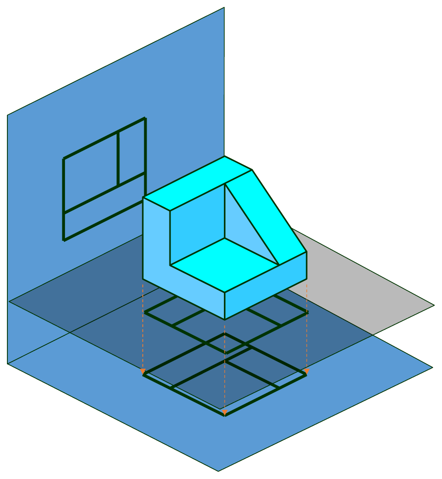

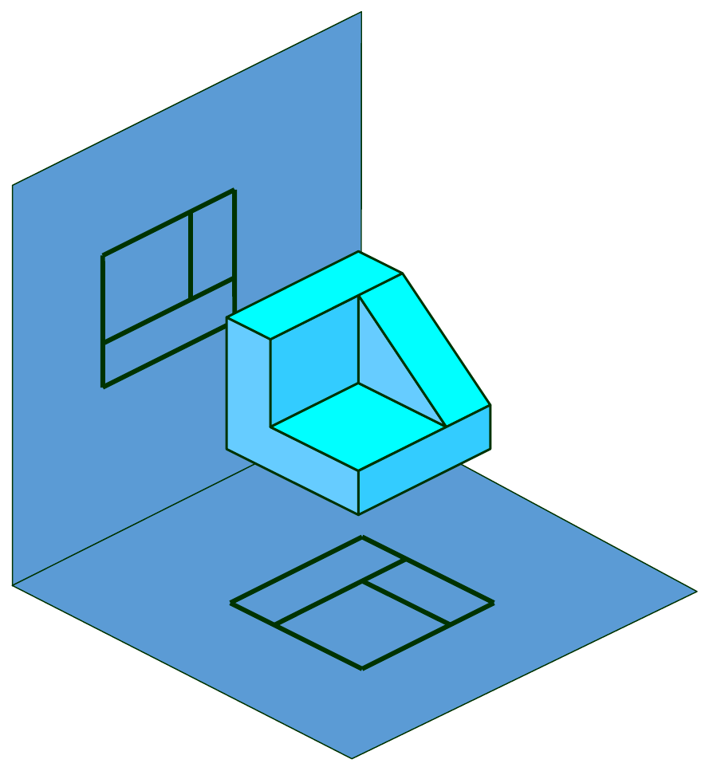

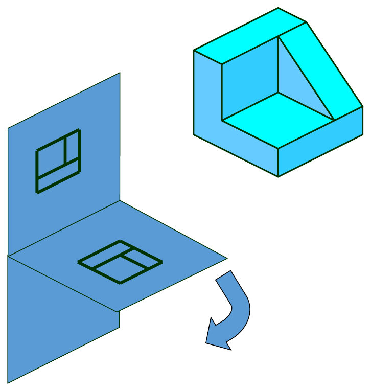

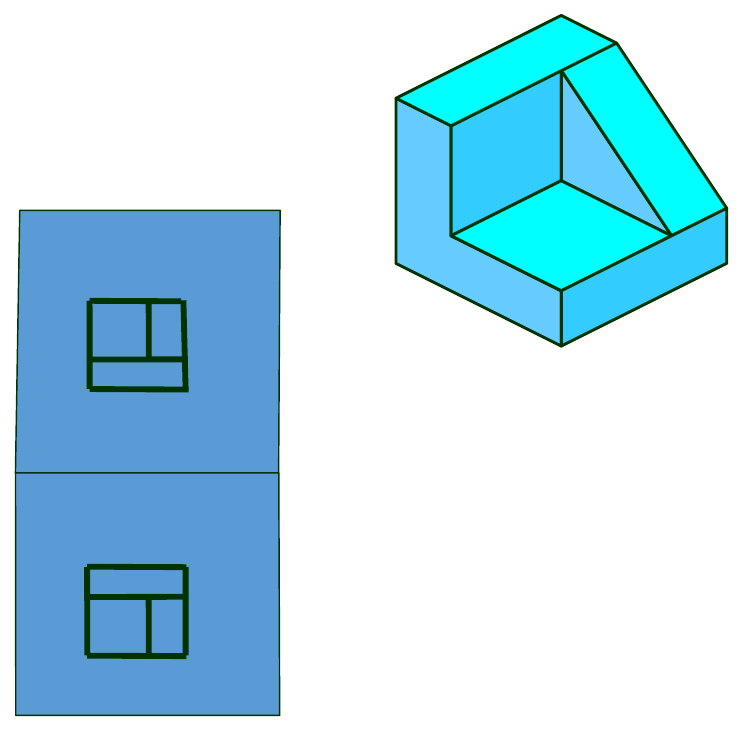

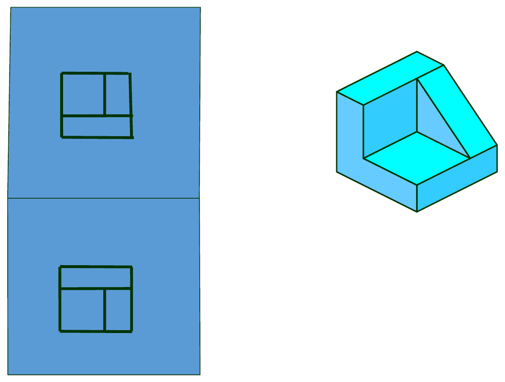

## El resultado: dos vistas en correspondencia

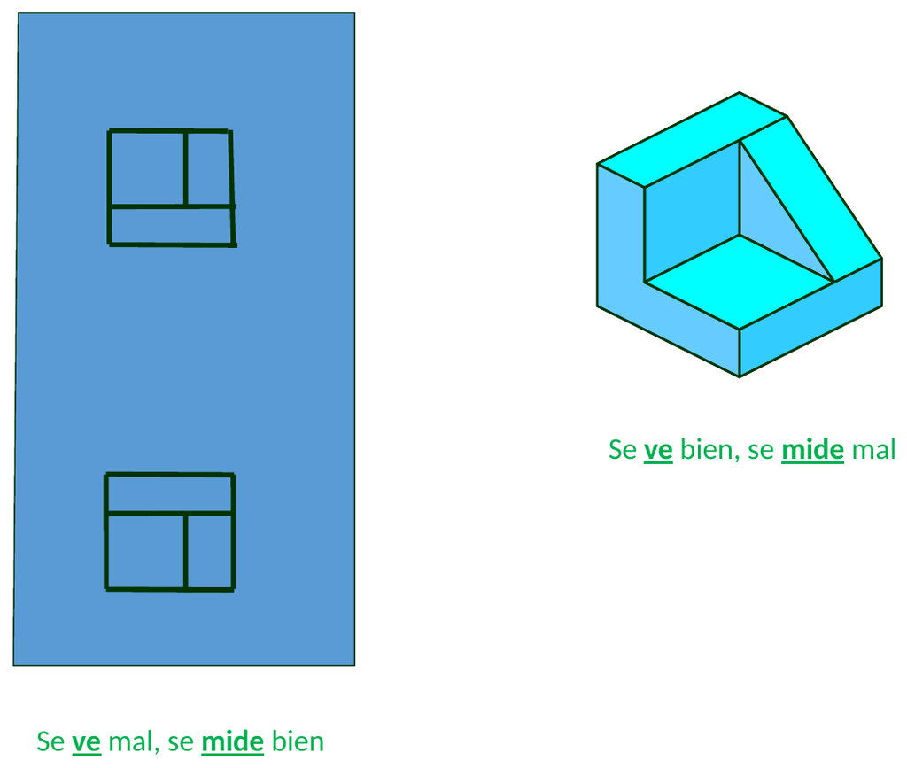

Cada vista por separado *se ve mal*… pero el conjunto **se mide bien**.

## Sistema diédrico directo

**Sistema Europeo**: el objeto se sitúa en el **1º cuadrante** → planta superior **ABAJO**

**Sistema Americano**: el objeto se sitúa en el **3º cuadrante** → planta superior **ARRIBA**

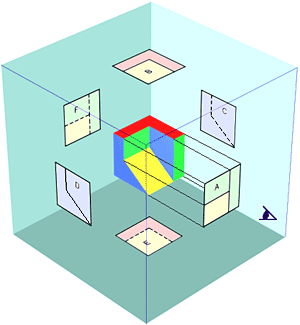

## 1º cuadrante: sistema europeo — “empujo”

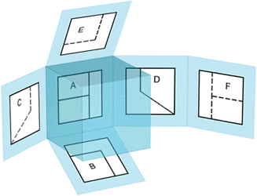

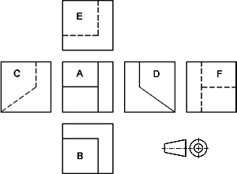

## 3º cuadrante: sistema americano — “tiro”

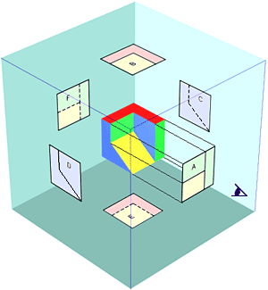

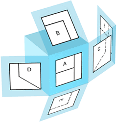

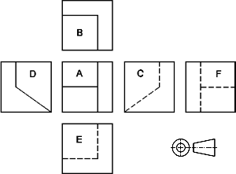

## Empezamos…: vistas

[figure not shown]

Tomaremos como **alzado** siempre la **vista más representativa** de la pieza: la que más información contiene, o con la que mejor se ve la geometría de la pieza en su conjunto.

*¿Qué otras vistas dibujo?* Una vez fijado el alzado, en el sistema europeo PUEDO representar hasta 5 vistas más. **¿Cuáles?** …DEPENDE

*¿De qué depende?* De que el objeto quede **COMPLETAMENTE DEFINIDO** → geometría constructiva

## Correspondencia entre vistas

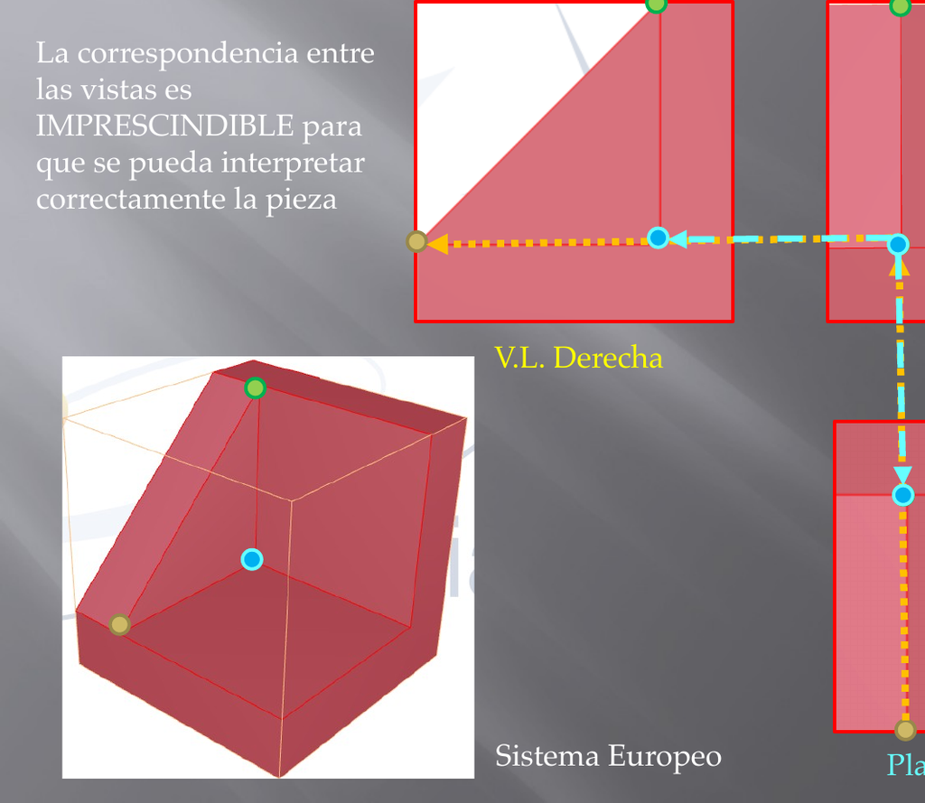

La correspondencia entre las vistas es **IMPRESCINDIBLE** para que se pueda interpretar correctamente la pieza.

## Entonces… ¿cuántas vistas o proyecciones necesito?

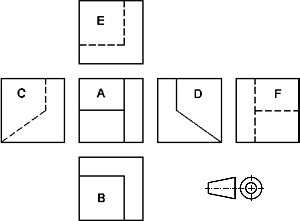

¿?

Las necesarias para que el objeto quede **completamente definido** — y ni una más.